# Assignment One

Krutika Joshi

# Basic Information

## Title of study: Preclinical efficacy of azacitidine and venetoclax for infant KMT2A-rearranged acute lymphoblastic leukemia reveals a new therapeutic strategy

**Data source**

The GSE number of the data set is GSE212591.

**What does this data set hold?**

- This study focuses on the effects of two different types of treatment on infants with KMT2A-rearranged B-cell acute lymphoblastic leukemia (ALL)(Cheung et al. 2023). ALL is an aggressive form of cancer that is rare in infants but once presented, causes high mortality rate due to the underdeveloped immune systems of the hosts(Mironova et al. 2023). In addition, the prognosis is not developed which further increases the mortality rates(Brown 2013). The first treatment consists of azacitidin with chemotherapy(Cheung et al. 2023). On the other hand, the second treatment consists of decitabine with chemotherapy(Cheung et al. 2023). The researchers focused on the promoter hypermethylation and the overexpression of BCL-2 as this is commonly expressed in ALL(Cheung et al. 2023).

**Why is the dataset of interest to you?**

- I have a profound interest in cancer biology as I have multiple family members that have been affected by this disease. Specifically, leukemia is the most prominent type of cancer in my lineage. I would like to learn more about managing data sets related to cancer as I plan to focus my grand school research/thesis on Acute lymphocytic leukemia in adult humans.

**Introduction to the data set used**

- The data set consists of gene expression levels of three different samples testing two different conditions(i.e azacitidin and decitabine). In addition these conditions are tested across multiple cell lines to understand the effect of the conditions/treatment.

**What are the control and test conditions of the dataset?**

- The control are the cell lines in the samples that have not been treated with azacitidin or decitabine. There are two test conditions, one where the cell lines have been treated with decitabine, and the other condition is where the cell lines have been treated with azacitidin.

**How many samples in each of the conditions of your dataset?**

- There were no such values in the data set. Every row was unique.

**Were there expression values that could not be mapped to current HUGO symbols?**

- The data set had all the genes mapped to HUGO symbols so I could not find any that did not map.

**Were there any outliers in your dataset? How were they handled in the originating paper? How many outliers were removed?**

- The data set was already pre-processed. The data set went through quality control. They removed low counts and applied normalization through TMM. Thus, I did not remove any outliers from the data set. I also felt like all the data points are important for the study as those genes might be differentially expressed thus causing the high/low count.

**How did you handle replicates?**

- I first checked to see if there were any duplicates by using the unique function. There were no duplicates thus I did not have to remove any rows.

**What is the final coverage of your dataset?**

- The final coverage was reads with >87% bases. This was the quality score used by the lab to filter out low counts data.

**Which normalization method did you use and why?**

- In the paper, the authors told us that they had applied TMM and filtered for low gene counts. I wanted to make sure the results they got and the results I got were the same so I also considered using TMM. In addition, I used TMM because this normalization method would allow me to see the genes that are differentially expressed across the different conditions and cell lines.

# Clean the data and map to HUGO symbols

### Downloading the data

GEOquery package used (Davis and Meltzer 2007)

Biomanager used (Morgan and Ramos 2023)

```r
# Start by cleaning the data
# Step one: Download GEOquery and knitr
if (!requireNamespace("BiocManager", quietly = TRUE))
    install.packages("BiocManager")
BiocManager::install("GEOquery")
library(GEOquery)

options(repos = c(CRAN = "https://cran.rstudio.com/"))
if (!requireNamespace("knitr", quietly = TRUE))
    install.packages("knitr")
library(knitr)

# Step two: get the GEO description of dataset
# GEO description of the data set
geoid <- "GSE212591"
gse <- getGEO(geoid ,GSEMatrix=FALSE)
gse@header$summary
```

```
## [1] "Transcriptomic profiling was performed on six cell lines derived from infants with KMT2A-rearranged ALL following treatment with two hypomethylating drugs (azacitidine and decitabine) administered at low doses for 72 hours in vitro. We identified changes in gene expression following treatmen…
```

```r
# Information about the platform
current_gpl <- names(GPLList(gse))[1]
current_gpl_info <- Meta(getGEO(current_gpl))
current_gpl
```

```
## [1] "GPL24676"
```

```r
# The current platform is:
current_gpl_info$title
```

```
## [1] "Illumina NovaSeq 6000 (Homo sapiens)"
```

```r
# The Submission data is:
current_gpl_info$submission_date
```

```
## [1] "Mar 02 2018"
```

```r
# Last update data:
current_gpl_info$last_update_date
```

```
## [1] "Nov 05 2018"
```

```r
# Organism:
current_gpl_info$organism
```

```
## [1] "Homo sapiens"
```

```r
# Number of GEO datasets that use this technology:
length(current_gpl_info$series_id)
```

```
## [1] 12914
```

```r
# Number of GEO samples that use this technology:
length(current_gpl_info$sample_id)
```

```
## [1] 847368
```

```r
# Information about the data processing
gse@gsms[[1]]@header$data_processing[1]
```

```
## [1] "Bioinformatic analysis was performed by AGRF following standardised pipelines, which involved demultiplexing (DRAGEN BCL Convert 07.021.609.3.9.3 pipeline)."
```

```r
# Expression data file information
sfilenames = getGEOSuppFiles(geoid, fetch_files = FALSE)
sfilenames$fname
```

```
## [1] "GSE212591_tmm_counts.txt.gz"
```

```r
# Choosing file
# My data set had only one file so I had to choose that
data_filename <- sfilenames$fname[1]
data_filename
```

```
## [1] "GSE212591_tmm_counts.txt.gz"
```

```r
# Get the expression Data
download_dir <- file.path(getwd())
#check to see if the file exists already before you download them
# only download files that we don't have from the set of
missing_files <- sfilenames$fname[!unlist(
  lapply(sfilenames$fname, FUN=function(x){
    file.exists(
      file.path(download_dir,geoid,x))}))]

if(length(missing_files) > 0){
  for(i in 1:length(missing_files)){
  #get the supplementary files
  sfiles = getGEOSuppFiles(geoid,
                           filter_regex = missing_files[i],
                           baseDir = download_dir,
                           fetch_files = TRUE)
  }
}

# Read the data
luk_data <- read.table(file.path(download_dir,geoid,data_filename), header=TRUE, check.names=TRUE)

# Check the dimensions
# There's almost 20k rows which match the description as the prof was saying in class
dim(luk_data)
```

```
## [1] 18048    55
```

```r
colnames(luk_data)
```

```
##  [1] "gene"    "CL1_C1"  "CL1_C2"  "CL1_C3"  "CL1_AZ1" "CL1_AZ2" "CL1_AZ3"
##  [8] "CL1_DE1" "CL1_DE2" "CL1_DE3" "CL2_C1"  "CL2_C2"  "CL2_C3"  "CL2_AZ1"
## [15] "CL2_AZ2" "CL2_AZ3" "CL2_DE1" "CL2_DE2" "CL2_DE3" "CL3_C1"  "CL3_C2"
## [22] "CL3_C3"  "CL3_AZ1" "CL3_AZ2" "CL3_AZ3" "CL3_DE1" "CL3_DE2" "CL3_DE3"
## [29] "CL4_C1"  "CL4_C2"  "CL4_C3"  "CL4_AZ1" "CL4_AZ2" "CL4_AZ3" "CL4_DE1"
## [36] "CL4_DE2" "CL4_DE3" "CL5_C1"  "CL5_C2"  "CL5_C3"  "CL5_AZ1" "CL5_AZ2"
## [43] "CL5_AZ3" "CL5_DE1" "CL5_DE2" "CL5_DE3" "CL6_C1"  "CL6_C2"  "CL6_C3"
## [50] "CL6_AZ1" "CL6_AZ2" "CL6_AZ3" "CL6_DE1" "CL6_DE2" "CL6_DE3"
```

```r
kable(luk_data[1:7,1:3], format = "html")
```

| gene | CL1_C1 | CL1_C2 |
| --- | --- | --- |
| A1BG | 10.8631577 | 11.9159330 |
| A1BG-AS1 | 9.0084722 | 8.6363184 |
| A2M | 0.9084174 | 0.4372819 |
| A4GALT | 0.0000000 | 0.0000000 |
| AAAS | 76.8748195 | 68.0337824 |
| AACS | 21.2342559 | 18.1472007 |
| AACSP1 | 0.0378507 | 0.1822008 |

```r
# Further investigation
gse@gsms[[1]]@header$characteristics_ch1
```

```
## [1] "disease state: KMT2A-rearranged infant ALL"
## [2] "cell line: PER490"
## [3] "genotype: t(4;11)"
## [4] "treatment: Control"
```

```r
gse@gsms[[1]]@header$title
```

```
## [1] "CL1_C1"
```

```r
gse@gsms[[1]]@header$geo_accession
```

```
## [1] "GSM6538111"
```

```r
# Based on the analysis, I was able to determine the meanings of the titles(column names)
# The CL stands for cell line and the number stands for sample: eg. CL5_C1

# First lets check if there is any NA data
any(is.na(luk_data))
```

```
## [1] FALSE
```

```r
# Result is false so there is no blank data

# Second lets see if there is duplicate rows
length(unique(rownames(luk_data)))
```

```
## [1] 18048
```

```r
length(rownames(luk_data))
```

```
## [1] 18048
```

```r
# They both are 18048 thus there is no duplicate rows

# Additional annotation
list_of_samples <- gse@gsms
luk_samples <- do.call(rbind,
                        lapply(list_of_samples,
                               FUN=function(x){
                                 c(x@header$title,
                                  x@header$characteristics_ch1)}
                               )
                        )

# Organize the data
colnames(luk_samples) <- c("title", "disease state","cell line", "genotype","treatment")
luk_samples[,'disease state'] <- gsub(luk_samples[,'disease state'], pattern = "disease state: ", replacement = "")
luk_samples[,'cell line'] <- gsub(luk_samples[,'cell line'], pattern = "cell line: ", replacement = "")
luk_samples[,'genotype'] <- gsub(luk_samples[,'genotype'], pattern = "genotype: ", replacement = "")
luk_samples[,'treatment'] <- gsub(luk_samples[,'treatment'], pattern = "treatment: ", replacement = "")
# Lets view what luk_samples holds
luk_samples
```

```
##            title     disease state                 cell line genotype
## GSM6538111 "CL1_C1"  "KMT2A-rearranged infant ALL" "PER490"  "t(4;11)"
## GSM6538112 "CL1_C2"  "KMT2A-rearranged infant ALL" "PER490"  "t(4;11)"
## GSM6538113 "CL1_C3"  "KMT2A-rearranged infant ALL" "PER490"  "t(4;11)"
## GSM6538114 "CL2_C1"  "KMT2A-rearranged infant ALL" "PER703"  "t(1;11)"
## GSM6538115 "CL2_C2"  "KMT2A-rearranged infant ALL" "PER703"  "t(1;11)"
## GSM6538116 "CL2_C3"  "KMT2A-rearranged infant ALL" "PER703"  "t(1;11)"
## GSM6538117 "CL3_C1"  "KMT2A-rearranged infant ALL" "PER784"  "t(11;13)"
## GSM6538118 "CL3_C2"  "KMT2A-rearranged infant ALL" "PER784"  "t(11;13)"
## GSM6538119 "CL3_C3"  "KMT2A-rearranged infant ALL" "PER784"  "t(11;13)"
## GSM6538120 "CL4_C1"  "KMT2A-rearranged infant ALL" "PER785"  "t(4;11)"
## GSM6538121 "CL4_C2"  "KMT2A-rearranged infant ALL" "PER785"  "t(4;11)"
## GSM6538122 "CL4_C3"  "KMT2A-rearranged infant ALL" "PER785"  "t(4;11)"
## GSM6538123 "CL5_C1"  "KMT2A-rearranged infant ALL" "PER826"  "t(11;13)"
## GSM6538124 "CL5_C2"  "KMT2A-rearranged infant ALL" "PER826"  "t(11;13)"
## GSM6538125 "CL5_C3"  "KMT2A-rearranged infant ALL" "PER826"  "t(11;13)"
## GSM6538126 "CL6_C1"  "KMT2A-rearranged infant ALL" "PER910"  "t(9;11)"
## GSM6538127 "CL6_C2"  "KMT2A-rearranged infant ALL" "PER910"  "t(9;11)"
## GSM6538128 "CL6_C3"  "KMT2A-rearranged infant ALL" "PER910"  "t(9;11)"
## GSM6538129 "CL1_AZ1" "KMT2A-rearranged infant ALL" "PER490"  "t(4;11)"
## GSM6538130 "CL1_AZ2" "KMT2A-rearranged infant ALL" "PER490"  "t(4;11)"
## GSM6538131 "CL1_AZ3" "KMT2A-rearranged infant ALL" "PER490"  "t(4;11)"
## GSM6538132 "CL2_AZ1" "KMT2A-rearranged infant ALL" "PER703"  "t(1;11)"
## GSM6538133 "CL2_AZ2" "KMT2A-rearranged infant ALL" "PER703"  "t(1;11)"
## GSM6538134 "CL2_AZ3" "KMT2A-rearranged infant ALL" "PER703"  "t(1;11)"
## GSM6538135 "CL3_AZ1" "KMT2A-rearranged infant ALL" "PER784"  "t(11;13)"
## GSM6538136 "CL3_AZ2" "KMT2A-rearranged infant ALL" "PER784"  "t(11;13)"
## GSM6538137 "CL3_AZ3" "KMT2A-rearranged infant ALL" "PER784"  "t(11;13)"
## GSM6538138 "CL4_AZ1" "KMT2A-rearranged infant ALL" "PER785"  "t(4;11)"
## GSM6538139 "CL4_AZ2" "KMT2A-rearranged infant ALL" "PER785"  "t(4;11)"
## GSM6538140 "CL4_AZ3" "KMT2A-rearranged infant ALL" "PER785"  "t(4;11)"
## GSM6538141 "CL5_AZ1" "KMT2A-rearranged infant ALL" "PER826"  "t(11;13)"
## GSM6538142 "CL5_AZ2" "KMT2A-rearranged infant ALL" "PER826"  "t(11;13)"
## GSM6538143 "CL5_AZ3" "KMT2A-rearranged infant ALL" "PER826"  "t(11;13)"
## GSM6538144 "CL6_AZ1" "KMT2A-rearranged infant ALL" "PER910"  "t(9;11)"
## GSM6538145 "CL6_AZ2" "KMT2A-rearranged infant ALL" "PER910"  "t(9;11)"
## GSM6538146 "CL6_AZ3" "KMT2A-rearranged infant ALL" "PER910"  "t(9;11)"
## GSM6538147 "CL1_DE1" "KMT2A-rearranged infant ALL" "PER490"  "t(4;11)"
## GSM6538148 "CL1_DE2" "KMT2A-rearranged infant ALL" "PER490"  "t(4;11)"
## GSM6538149 "CL1_DE3" "KMT2A-rearranged infant ALL" "PER490"  "t(4;11)"
```

[output cut: 55 more lines]

```
## GSM6538150 "Decitabine-treated"
## GSM6538151 "Decitabine-treated"
## GSM6538152 "Decitabine-treated"
## GSM6538153 "Decitabine-treated"
## GSM6538154 "Decitabine-treated"
## GSM6538155 "Decitabine-treated"
## GSM6538156 "Decitabine-treated"
## GSM6538157 "Decitabine-treated"
## GSM6538158 "Decitabine-treated"
## GSM6538159 "Decitabine-treated"
## GSM6538160 "Decitabine-treated"
## GSM6538161 "Decitabine-treated"
## GSM6538162 "Decitabine-treated"
## GSM6538163 "Decitabine-treated"
## GSM6538164 "Decitabine-treated"
```

### Assess

```r
luk_samples_dt <- data.table::data.table(luk_samples)
# Lets look at the samples in each treatment(i.e control, azacitidine, decitabine)
luk_samples_dt[, .(count = .N), by = luk_samples_dt$treatment]
```

```
##         luk_samples_dt count
## 1:             Control    18
## 2: Azacitidine-treated    18
## 3:  Decitabine-treated    18
```

```r
# Lets look at the samples in each cell line
luk_samples_dt[, .(count = .N), by = luk_samples_dt$genotype]
```

```
##    luk_samples_dt count
## 1:        t(4;11)    18
## 2:        t(1;11)     9
## 3:       t(11;13)    18
## 4:        t(9;11)     9
```

### Mapping

```r
# The data set is already mapped to contain HUGO gene symbols as row identifiers
```

### Cleaning

```r
if (!requireNamespace("BiocManager", quietly = TRUE))
    install.packages("BiocManager")

BiocManager::install("edgeR")
library(edgeR)
```

```r
# I set the min read value to be 10
min_num_samples <- 10
luk_data_matrix <- as.matrix(luk_data)
# When I used the code from the slide I got an error when the cpm function was applied
# where the error said we need numeric data
# So I figured the error occurs because the first column is a char vector(i.e gene name)
# so ill remove it temporarily and add it later
gene_names <- luk_data_matrix[, 1]

# Now ill convert the rest of the columns to numeric matrix except the first one
luk_data_matrix <- luk_data_matrix[, -1]
luk_data_matrix <- apply(luk_data_matrix, 2, as.numeric)
luk_data_matrix_cpm <- as.matrix(luk_data_matrix)

# Complete the cpm step
cpm_data <- edgeR::cpm(luk_data_matrix_cpm)

# Now we will filter the data
keep <- rowSums(cpm_data > 1) >= min_num_samples
filtered_data_matrix <- luk_data_matrix_cpm[keep, ]
```

# Normalization

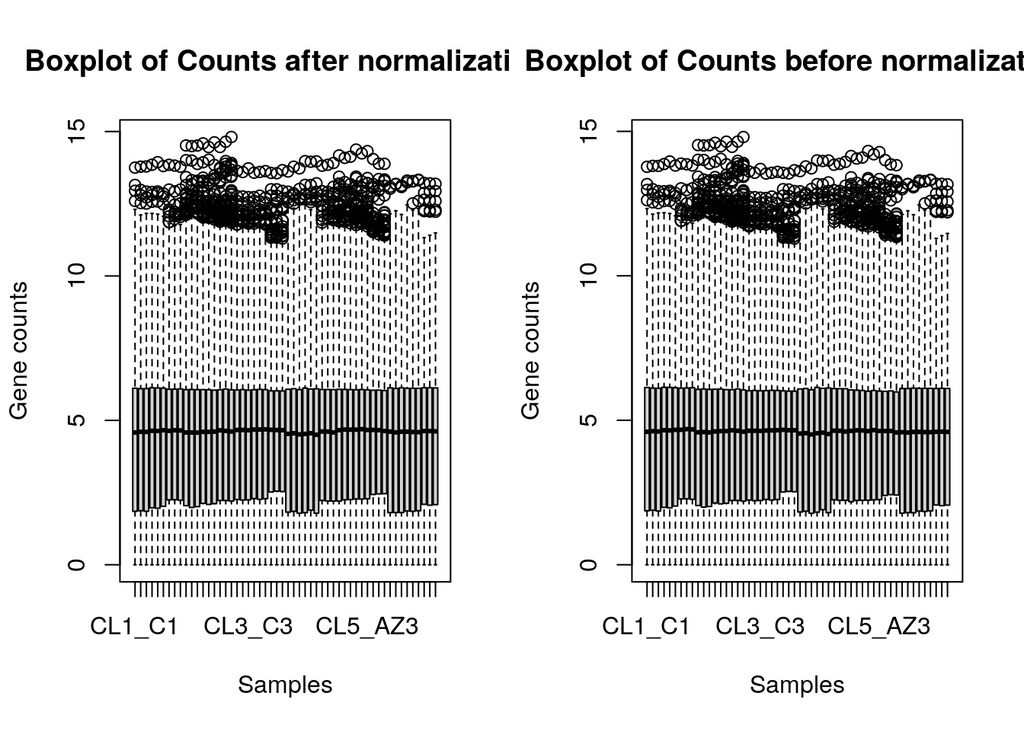

```r
# I will apply TMM
d = DGEList(counts=filtered_data_matrix, group=luk_samples_dt$treatment)
# calculate normalization factors
d = calcNormFactors(d)
# apply cpm on the normalized data.
# This is the final data set the question in normalization is asking for
normalized_counts <- cpm(d)

# To see the difference in the data before and after normalization, I will use a box plot
par(mfrow=c(1, 2))
# Added a plus 1 because after normalization, the counts might have been set to 0
log_normalized_counts <- log2(normalized_counts+1)
log_filtered_data_matrix <- log2(filtered_data_matrix+1)
boxplot(log_normalized_counts, main = "Boxplot of Counts after normalization", xlab = "Samples", ylab = "Gene counts")
boxplot(log_filtered_data_matrix, main = "Boxplot of Counts before normalization", xlab = "Samples", ylab = "Gene counts")
```

```r
par(mfrow=c(1, 1))
# The box plots before and after seem to be the same but this makes sense as in the paper, the authors had told us they had already applied TMM
# and filtered for low gene count.
```

# Analysis/Assessment

### Multidimensional scaling (MDS)

The MDS allows for visualization of similarities and differences in gene expression data across different samples or conditions. (Tzeng, Lu, and Li 2008) In this case, we can see the difference in the gene expression for the control, decitabine and azacitidine. The further the distance on plot for certain points, the more different their gene expressions. In this case, decitabine seems to have the most differentially expressed genes against the control compared to azacitidine and control. The last thing to note is that the clusting of points can show different gene expressions across different conditions. (Tzeng, Lu, and Li 2008) In this case, there are clusters observed where decitabine and azacitidine are grouped together, azacitidine and control are grouped together and lastly, there is a solo group with control on the top right.

Package used: Limms (Ritchie et al. 2015)

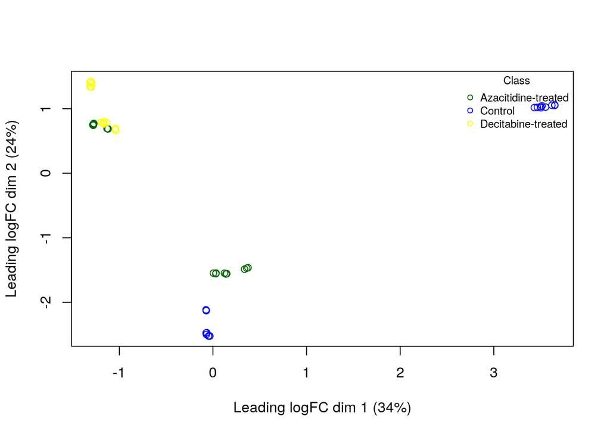

```r
limma::plotMDS(d, labels=NULL, pch = 1, col = c("darkgreen","blue","yellow")[factor(luk_samples_dt$treatment)])
legend("topright", legend=levels(factor(luk_samples_dt$treatment)), pch=c(1), col= c("darkgreen","blue","yellow"),title="Class", bty = 'n', cex = 0.75)
```

### Dispersion Analysis

Dispersion Analysis focuses more on the biological variability instead of the technical variability. (Ouyang et al. 2016) It tells us the spread of the data on a number line. (Ouyang et al. 2016) The closer the points are to the line, the lesser differentialy expressed(DE) genes are present in the data set. (Ouyang et al. 2016) In this case, there seems to be quiet a lot points that are away from the line thus we can say there are quiet a lot of DE genes.

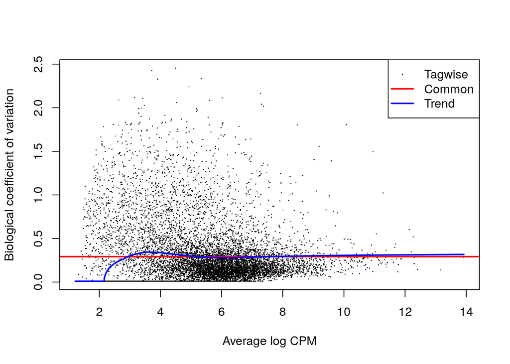

```r
model_design <- model.matrix(~luk_samples_dt$treatment+luk_samples_dt$`cell line`)
d <- estimateDisp(d, model_design)
plotBCV(d,col.tagwise = "black",col.common = "red",)
```

### Mean-variance

The plot produced by Mean-variance Analysis is to examine if the assumption of the data set following a negative binomial distribution is accepted (Levy and Levy 2004). If the data lies near the blue line, we can assume the data set follows a negative binomial distribution. On the other hand, if the data points lie near the back line, then they follow a poisson distribution. In this graphs case, we can say the data set follows a negative binomial distribution as most of the points are near the blue line.

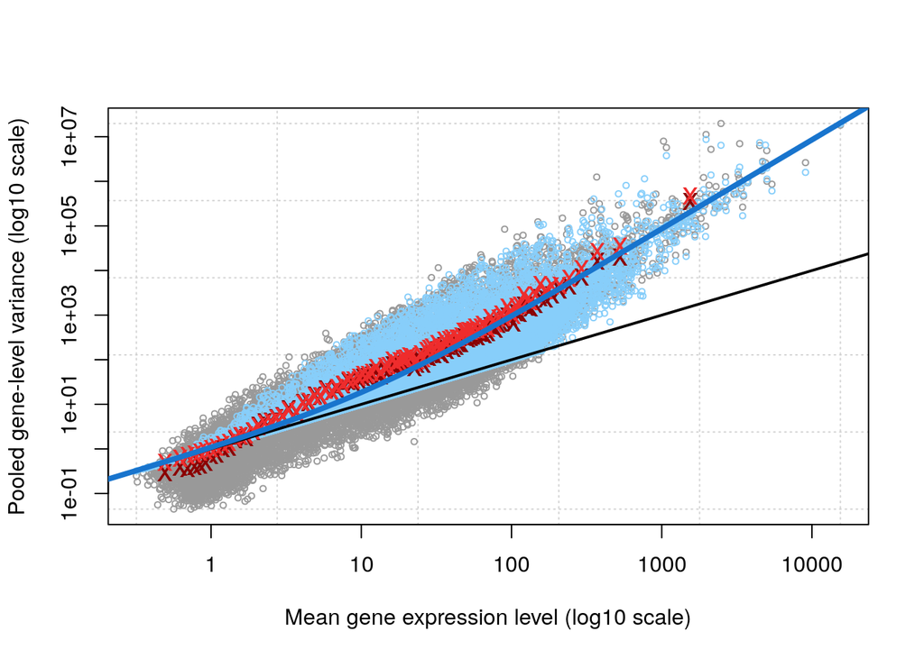

```r
plotMeanVar(d, show.raw.vars = TRUE, show.tagwise.vars=TRUE, show.ave.raw.vars = TRUE, NBline=TRUE, show.binned.common.disp.vars = TRUE)
```

# Identifier mapping

The data set provided was already Hugo mapped and it did not contain any information identifying the genes(e.g Ensembl number, etc.) thus I could not proceed further with the identifier mapping.

```r
write.table(normalized_counts, file.path(getwd(),geoid, paste(geoid,"GSE212591_tmm_counts.txt",sep="_")),quote = FALSE,sep="\t",row.names = TRUE)
```

# References for packages

Robinson MD, McCarthy DJ and Smyth GK (2010). edgeR: a Bioconductor package for differential expression analysis of digital gene expression data. Bioinformatics 26, 139-140

Xie Y (2023). *knitr: A General-Purpose Package for Dynamic Report Generation in R*. R package version 1.45, https://yihui.org/knitr/.

Brown, Patrick. 2013. “Treatment of Infant Leukemias: Challenge and Promise.” *Hematology / the Education Program of the American Society of Hematology. American Society of Hematology. Education Program* 2013: 596–600. https://doi.org/10.1182/asheducation-2013.1.596.

Cheung, Laurence C., Carlos Aya-Bonilla, Mark N. Cruickshank, Sung K. Chiu, Vincent Kuek, Denise Anderson, Grace-Alyssa Chua, et al. 2023. “Preclinical Efficacy of Azacitidine and Venetoclax for Infant KMT2A-Rearranged Acute Lymphoblastic Leukemia Reveals a New Therapeutic Strategy.” *Leukemia* 37 (1): 61–71. https://doi.org/10.1038/s41375-022-01746-3.

Davis, Sean, and Paul Meltzer. 2007. “GEOquery: A Bridge Between the Gene Expression Omnibus (GEO) and BioConductor.” *Bioinformatics* 14: 1846–47.

Levy, Haim, and Moshe Levy. 2004. “Prospect Theory and Mean-Variance Analysis.” *The Review of Financial Studies* 17 (4): 1015–41. https://www.jstor.org/stable/3598057.

Mironova, Denitza, Chitra M. Saraswati, Peter Downie, Chow Yee Lai, Eleanor Cook, Vickyanne Carruthers, Perla Moukhaiber, et al. 2023. “Late Effects in Survivors of Infant Acute Lymphoblastic Leukaemia—a Study of the Australian and New Zealand Children’s Haematology/Oncology Group.” *Blood Cancer Journal* 13 (1): 1–4. https://doi.org/10.1038/s41408-023-00924-5.

Morgan, Martin, and Marcel Ramos. 2023. *BiocManager: Access the Bioconductor Project Package Repository*. https://CRAN.R-project.org/package=BiocManager.

Ouyang, Weiwei, Qiang An, Jinying Zhao, and Huaizhen Qin. 2016. “Integrating Mean and Variance Heterogeneities to Identify Differentially Expressed Genes.” *BMC Bioinformatics* 17 (1): 497. https://doi.org/10.1186/s12859-016-1393-y.

Ritchie, Matthew E, Belinda Phipson, Di Wu, Yifang Hu, Charity W Law, Wei Shi, and Gordon K Smyth. 2015. “limma Powers Differential Expression Analyses for RNA-Sequencing and Microarray Studies.” *Nucleic Acids Research* 43 (7): e47. https://doi.org/10.1093/nar/gkv007.

Tzeng, Jengnan, Henry Horng-Shing Lu, and Wen-Hsiung Li. 2008. “Multidimensional Scaling for Large Genomic Data Sets.” *BMC Bioinformatics* 9 (1): 179. https://doi.org/10.1186/1471-2105-9-179.